# Diseño Completamente Aleatorizado

Diseño de Experimentos

Heriberto Felizzola Jimenez

# Diseño completamente aleatorizado - ANOVA

Un equipo de mejora investiga el efecto de cuatro métodos de ensamble A, B, C y D, sobre el tiempo de ensamble en minutos. En este caso se tiene a = 4 tratamientos y n = 4 observaciones por tratamiento.

En primera instancia, la estrategia experimental es aplicar cuatro veces los cuatro métodos de ensamble en orden completamente aleatorio (las N = 16 pruebas en orden aleatorio).

Si se usa el diseño completamente al azar (DCA), se supone que, además del método de ensamble, no existe ningún otro factor que influya de manera significativa sobre la variable de respuesta (tiempo de ensamble).

```r
Ord.Corrida <-  c(1:16)
Metodo <-  c('C','C','A','B','B','D','D','C','A','D','A','D','B','C','A','B')
Tiempo <-  c(11,13,8,7,9,10,12,11,7,9,6,11,8,16,8,10)
df1 <-  data.frame(Ord.Corrida = Ord.Corrida,
                     Metodo = factor(Metodo),
                     Tiempo = Tiempo)
```

## Análisis exploratorio de los datos

A continuación se presenta la gráfica de valores individuales.

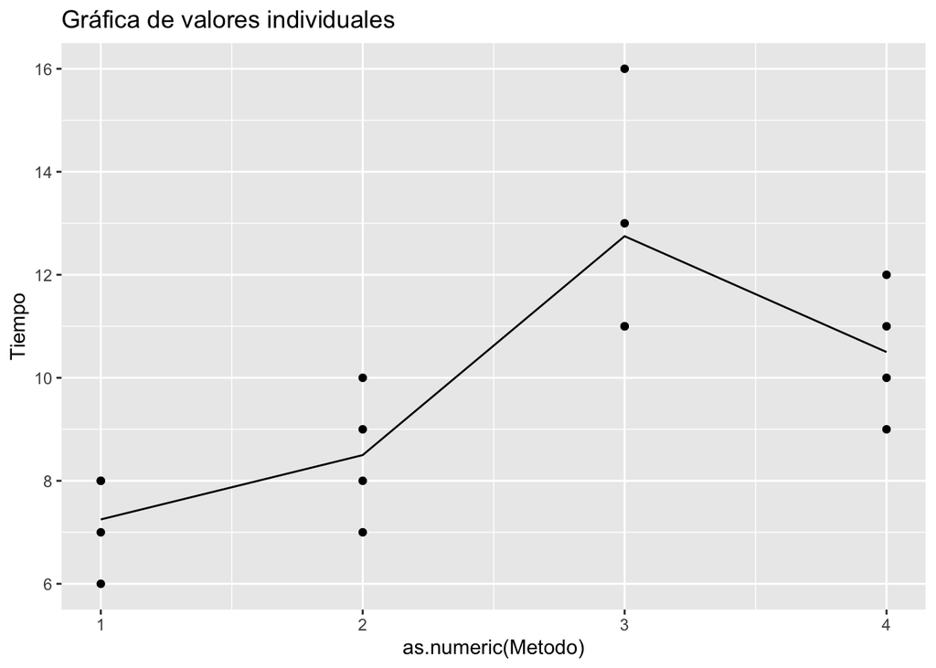

```r
p <- ggplot(data = df1, mapping = aes(x = as.numeric(Metodo), y = Tiempo))
p + geom_point() +
  stat_summary(geom = "line", fun.y = mean) +
  ggtitle(label = "Gráfica de valores individuales")
```

## Hipotesis

Las hipotesis que se plantean en un DCA son:

$$H_{0}: \mu_{1} = \mu_{2} = ... = \mu_{a} = \mu \\
H_{a}: \mu_{i} \neq \mu_{j}\: para \: algun \: i \neq i \\$$

El modelo estadistico lineal para el DCA:

$$Y_{ij} = \mu + \tau_{i} + \varepsilon_{ij}$$

## Análisis de varianza

El anova para un DCA:

```r
lm.DCA <-  lm(formula = Tiempo ~ Metodo, data = df1) # Primero se construye un modelo lineal
anova(lm.DCA) # Se genera el ANOVA para el modelo lineal
```

|  | Df | Sum Sq | Mean Sq | F value | Pr(>F) |
| --- | --- | --- | --- | --- | --- |
| Metodo | 3 | 69.5 | 23.166667 | 9.423729 | 0.001770946 |
| Residuals | 12 | 29.5 | 2.458333 | NA | NA |

Con valor-p = 0.00177 y un $\alpha = 0.05$, se rechaza la hipotesis nula, por tanto, se infiere que no todas las medias de los cuatro tratamiento son iguales.

## Comparaciones

### Metodo LSD

Un prueba LSD se presenta a continuación:

```r
# Se debe instalar el paquete agricolae, en caso de no tenerlo instalado
LSD <-  LSD.test(y = aov(lm.DCA),
                 trt = "Metodo",
                 alpha = 0.05, group = TRUE, console = TRUE)
```

```
##
## Study: aov(lm.DCA) ~ "Metodo"
##
## LSD t Test for Tiempo
##
## Mean Square Error:  2.458333
##
## Metodo,  means and individual ( 95 %) CI
##
##   Tiempo       std r       LCL       UCL Min Max
## A   7.25 0.9574271 4  5.541912  8.958088   6   8
## B   8.50 1.2909944 4  6.791912 10.208088   7  10
## C  12.75 2.3629078 4 11.041912 14.458088  11  16
## D  10.50 1.2909944 4  8.791912 12.208088   9  12
##
## Alpha: 0.05 ; DF Error: 12
## Critical Value of t: 2.178813
##
## least Significant Difference: 2.415602
##
## Treatments with the same letter are not significantly different.
##
##   Tiempo groups
## C  12.75      a
## D  10.50     ab
## B   8.50     bc
## A   7.25      c
```

A continuación se presenta una gráfica con los resultados de las comparaciones bajo el método LSD:

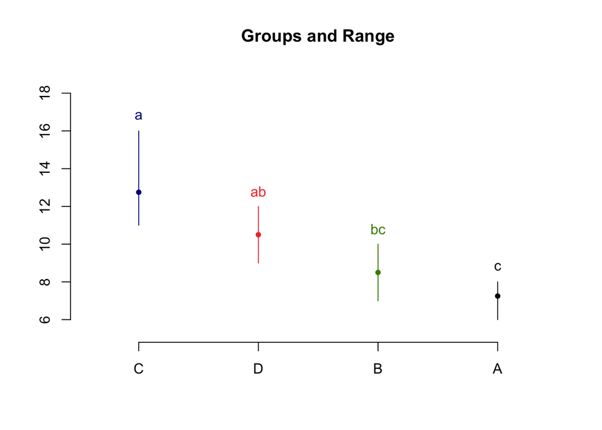

```r
plot.group(LSD)
```

### Metodo Tukey

Una prueba de Tukey se presenta a continuación:

```r
Tukey <-  HSD.test(y = aov(lm.DCA),
                   trt = "Metodo",
                   alpha = 0.05,
                   group = TRUE, console = TRUE)
```

```
##
## Study: aov(lm.DCA) ~ "Metodo"
##
## HSD Test for Tiempo
##
## Mean Square Error:  2.458333
##
## Metodo,  means
##
##   Tiempo       std r Min Max
## A   7.25 0.9574271 4   6   8
## B   8.50 1.2909944 4   7  10
## C  12.75 2.3629078 4  11  16
## D  10.50 1.2909944 4   9  12
##
## Alpha: 0.05 ; DF Error: 12
## Critical Value of Studentized Range: 4.19866
##
## Minimun Significant Difference: 3.291555
##
## Treatments with the same letter are not significantly different.
##
##   Tiempo groups
## C  12.75      a
## D  10.50     ab
## B   8.50      b
## A   7.25      b
```

Gráfica para las comparaciones por el método de Tukey:

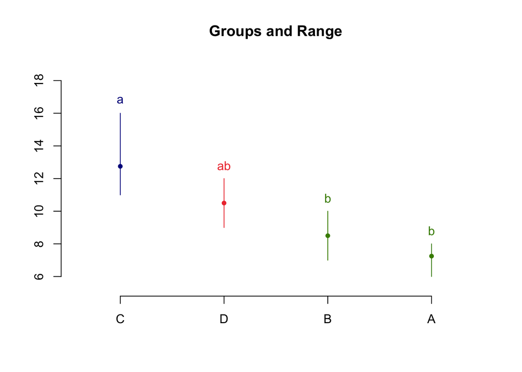

```r
plot.group(Tukey)
```

## Verificación de supuestos

### Normalidad

A continuación una gráfica de normalidad para los residuales:

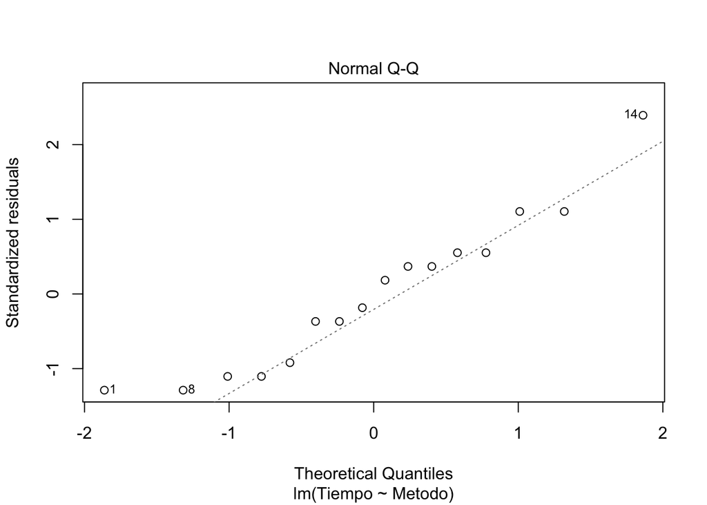

```r
# wich = 2, indica que se gráfica la de probabilidad
plot(x = lm.DCA, which = 2)
```

Un prueba Anderson-Darling se muestra a continuación:

```r
ad.test(residuals(lm.DCA))
```

```
##
##  Anderson-Darling normality test
##
## data:  residuals(lm.DCA)
## A = 0.34655, p-value = 0.435
```

Con valor p de 0.435 no se rechaza Ho por tanto se concluye que los residuales siguen una distribución normal.

### Homocedasticidad

A continuación se presentan algunas gráfica de homocedasticidad:

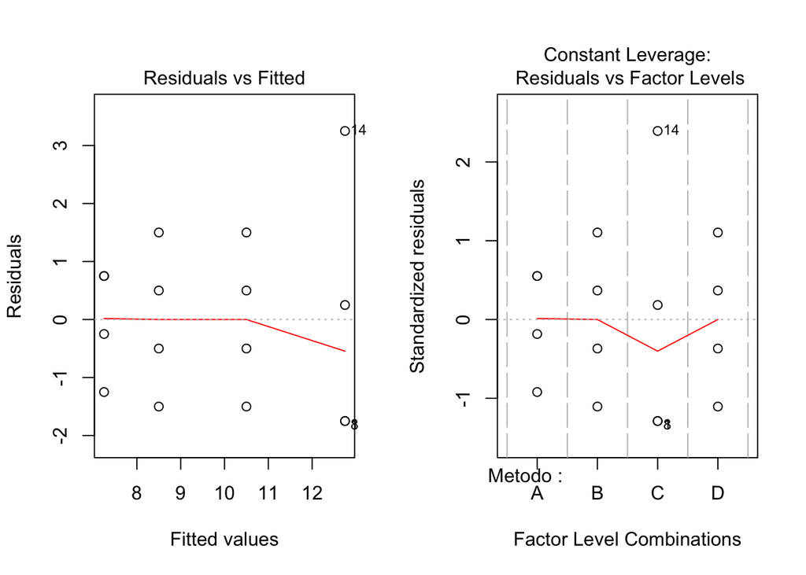

```r
par(mfrow = c(1,2))
plot(x = lm.DCA, which = c(1,5))
```

Un prueba de levene se presenta a continuación:

```r
levene.test(y = df1$Tiempo, group = df1$Metodo, location = "median")
```

```
##
##  Modified robust Brown-Forsythe Levene-type test based on the
##  absolute deviations from the median
##
## data:  df1$Tiempo
## Test Statistic = 0.94737, p-value = 0.4485
```

Con un valor p de 0.4485 se concluye que los datos son homocedasticos.

### Independencia

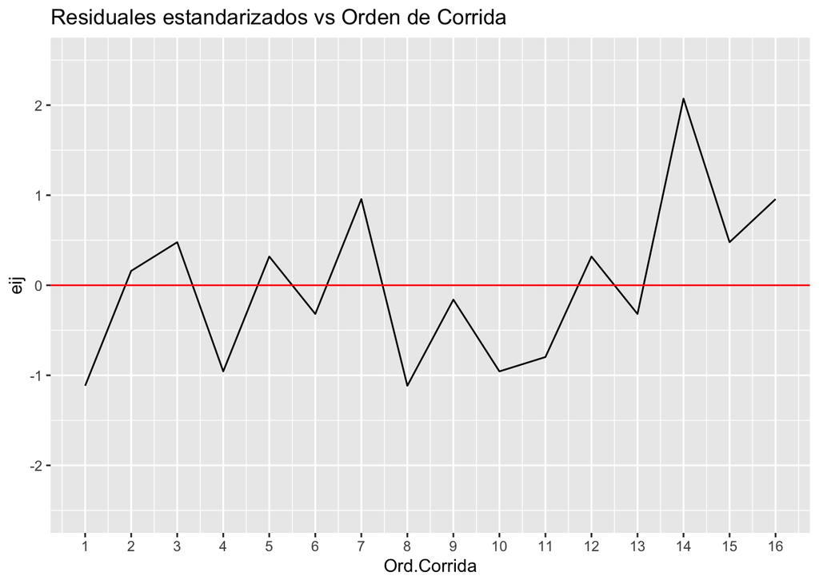

```r
df1$Eij <- residuals(lm.DCA) # Se extraen los residuales del modelo lineal
df1$eij <- df1$Eij/sqrt(2.46) # Se calcula los residuales estandarizados
ggplot(data = df1, mapping = aes(x = Ord.Corrida,y = eij)) +
  geom_line() +
  scale_x_continuous(breaks = c(1:16)) +
  scale_y_continuous(limits = c(-2.5,2.5)) +
  geom_hline(yintercept = 0, col = "red") +
  ggtitle("Residuales estandarizados vs Orden de Corrida")
```

Un prueba de corridas ó rachas.

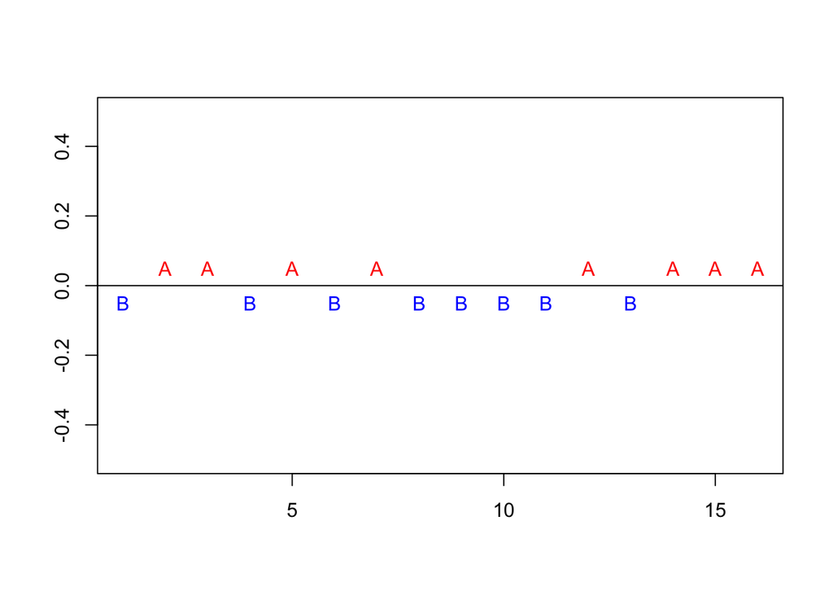

```
##
##  Runs Test - Two sided
##
## data:  df1$eij
## Standardized Runs Statistic = 0.51755, p-value = 0.6048
```

```r
runs.test(y = df1$eij, plot.it = T)
```

# Metódos no paramétricos para el análisis de un DCA

En un experimento para determinar cuál de tres diferentes sistemas de misiles es preferible, se mide la tasa de combustión del propulsor.

Utilice la prueba de Kruskal-Wallis y un nivel de significancia de $\alpha = 0.05$ para probar la hipótesis de que las tasas de combustión del propulsor son iguales para los tres sistemas de misiles.

```r
Sistema <- factor(c(1,1,1,1,1,2,2,2,2,2,2,3,3,3,3,3,3,3,3))
x <- c(24.0,16.7,22.8,19.8,18.9,23.2,19.8,18.1,17.6,20.2,17.8,
       18.4,19.1,17.3,17.3,19.7,18.9,18.8,19.3)
Rij = rank(x)
df2 <- data.frame(Sistema = Sistema, X = x, Rij = Rij)
```

## Análisis gráfico de los rangos

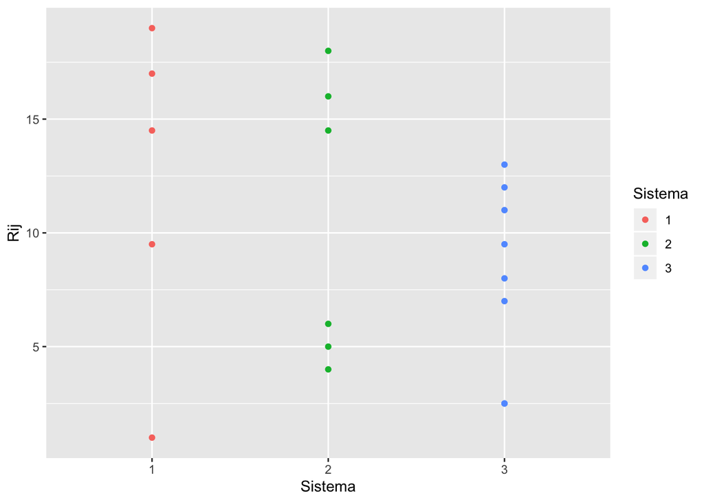

```r
p2 <- ggplot(data = df2, mapping = aes(x = Sistema, y = Rij, col = Sistema))
p2 + geom_point()
```

## Prueba de Kruskal-Wallis

A continuación se presenta la prueba:

```r
kruskal.test(x~Sistema, data = df2)
```

```
##
##  Kruskal-Wallis rank sum test
##
## data:  x by Sistema
## Kruskal-Wallis chi-squared = 1.663, df = 2, p-value = 0.4354
```

## Comparaciones de medias para el método de Kruskal-Wallis

A continuación se presentan las comparaciones de tratamientos cuando se ha utilizando el método de Kruskal-Wallis

```r
kru.test <- kruskal(df2$X, trt = df2$Sistema, group = TRUE, console = TRUE)
```

```
##
## Study: df2$X ~ df2$Sistema
## Kruskal-Wallis test's
## Ties or no Ties
##
## Critical Value: 1.662995
## Degrees of freedom: 2
## Pvalue Chisq  : 0.4353969
##
## df2$Sistema,  means of the ranks
##
##      df2.X r
## 1 12.20000 5
## 2 10.58333 6
## 3  8.18750 8
##
## Post Hoc Analysis
##
## t-Student: 2.119905
## Alpha    : 0.05
## Groups according to probability of treatment differences and alpha level.
##
## Treatments with the same letter are not significantly different.
##
##      df2$X groups
## 1 12.20000      a
## 2 10.58333      a
## 3  8.18750      a
```

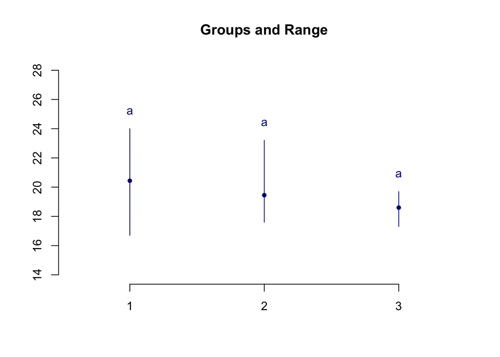

```r
plot.group(kru.test)
```